# Somalia Hunger Visualizations

## Prevalence of Undernourishment

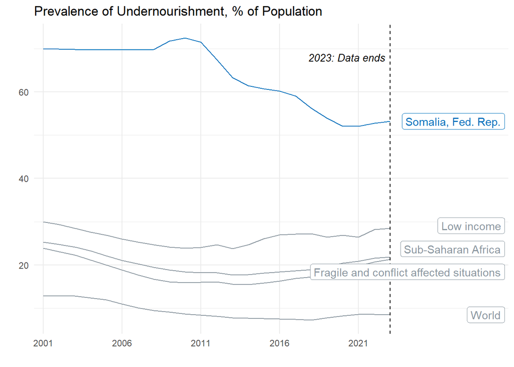

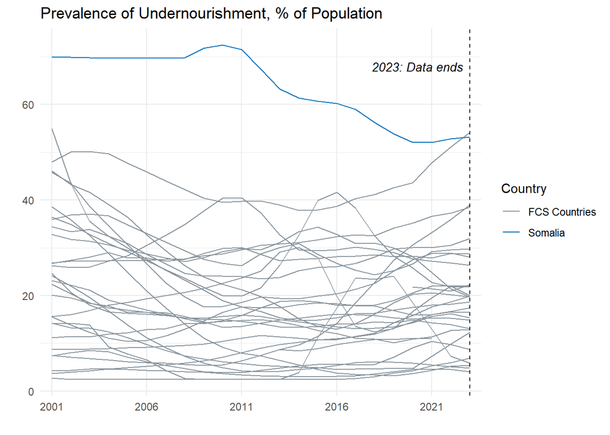

Somalia’s undernourishment rate plotted against individual fragile and conflict-affected states, 2001–2023.

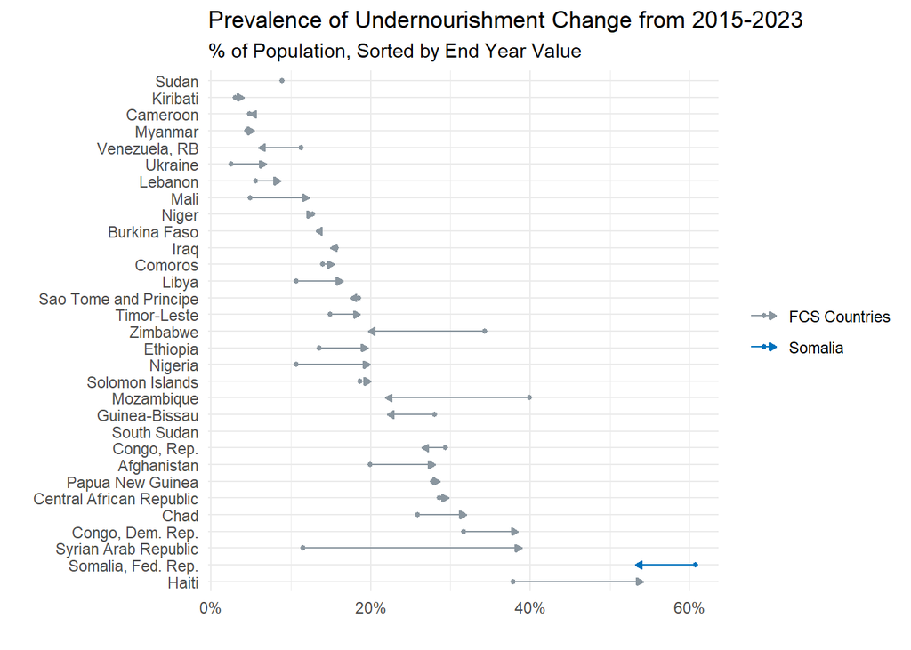

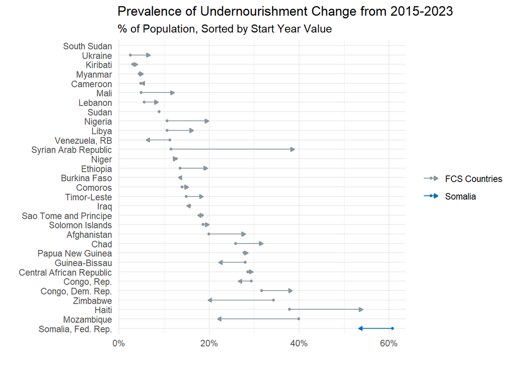

Change in undernourishment prevalence across FCS countries from 2015 to 2023, ranked by 2023 rate and by 2015 rate. Although Somalia has improved a great deal in recent years, it still lags the rest of the world.

## FIES Data

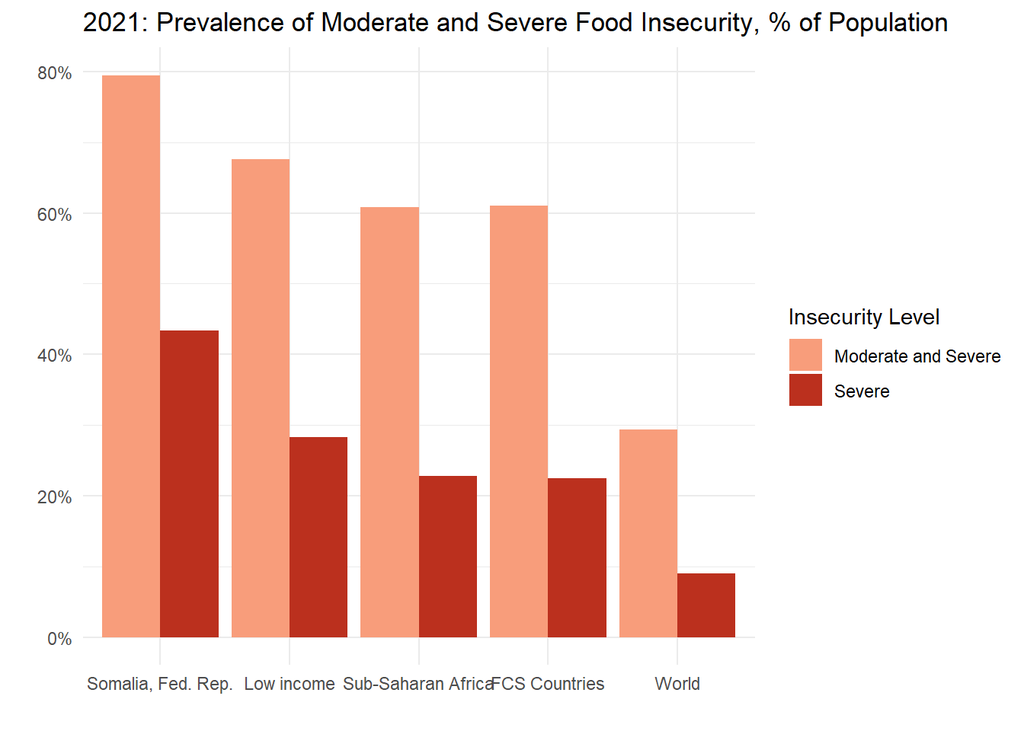

Prevalence of moderate-and-severe and severe food insecurity in Somalia compared to peer country groups, 2021.

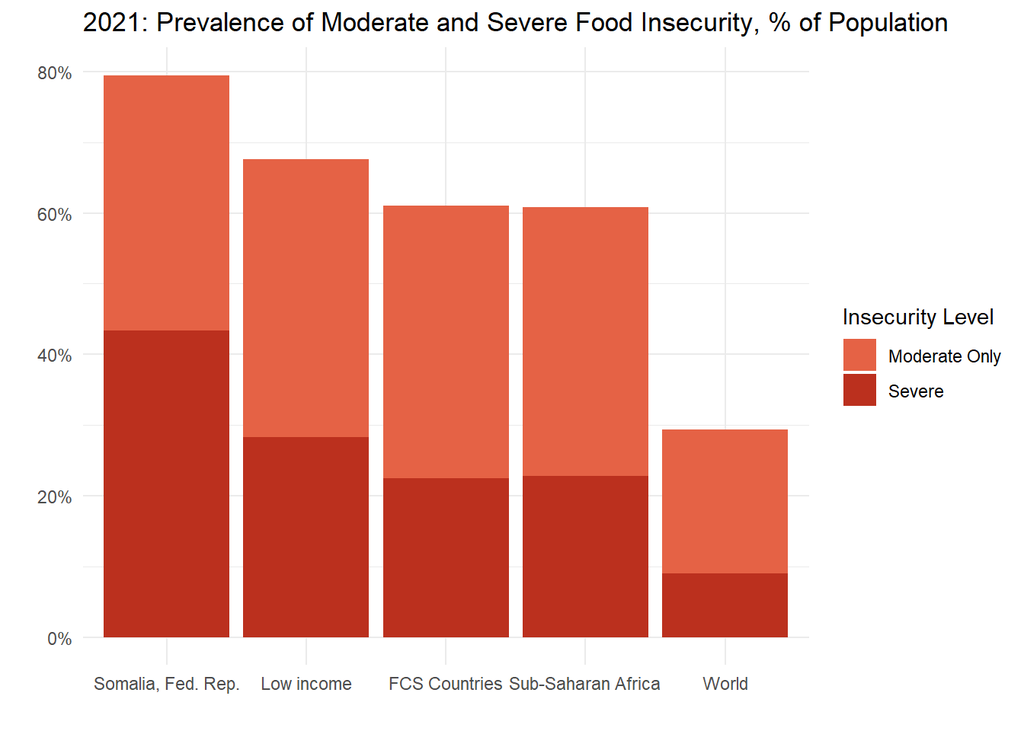

The same data shown as stacked bars, separating the severe and moderate-only components of food insecurity.

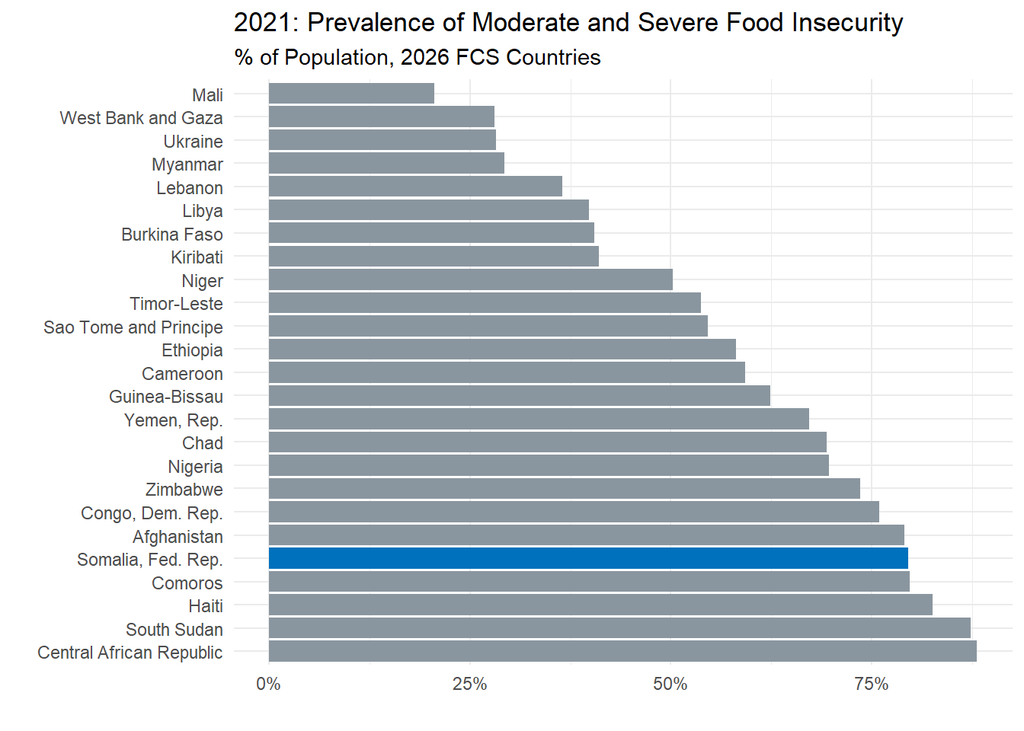

Combined moderate and severe food insecurity rates across all 2026 FCS countries, 2021. Somalia ranks among the highest.

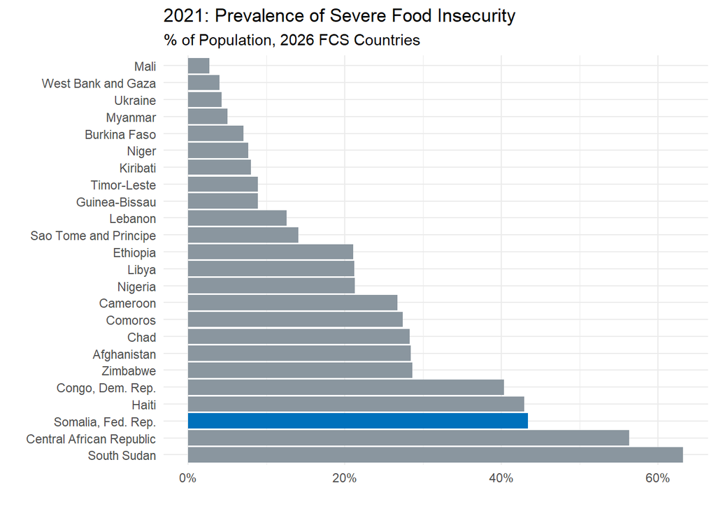

Severe food insecurity rates across FCS countries, 2021. Somalia falls in the worst tier alongside Haiti and DRC.

## IPC data

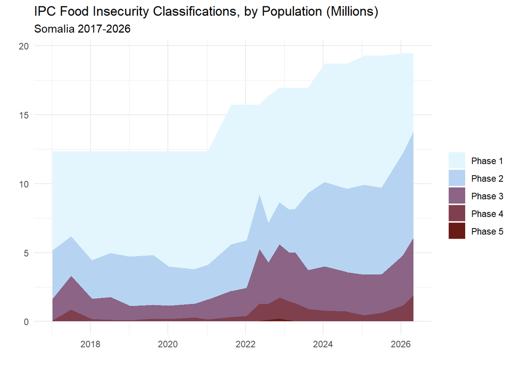

Population in each IPC food insecurity phase in Somalia, 2017–2026, measured in millions of people.

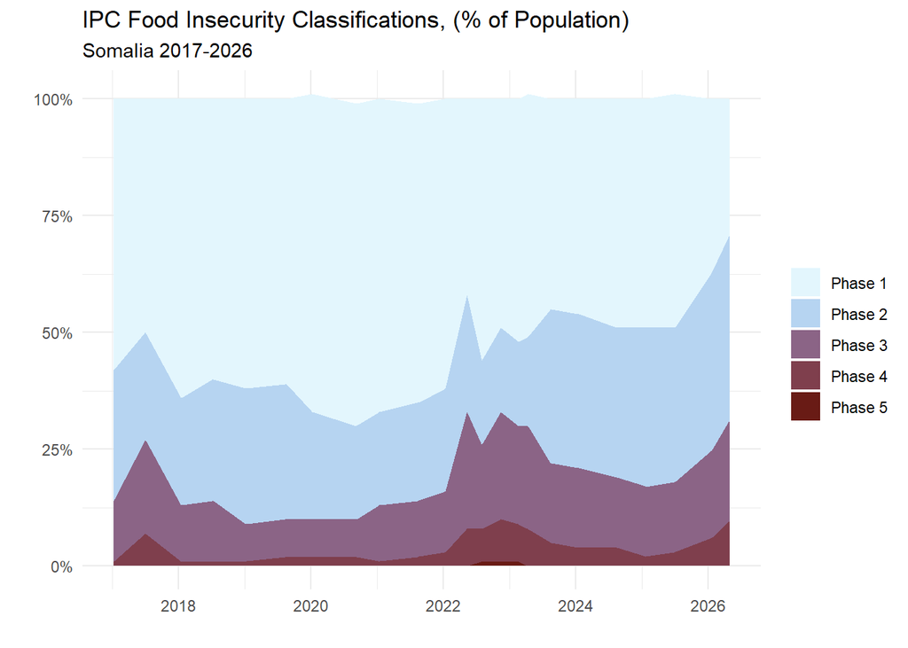

The same IPC phase breakdown expressed as a share of Somalia’s total assessed population.

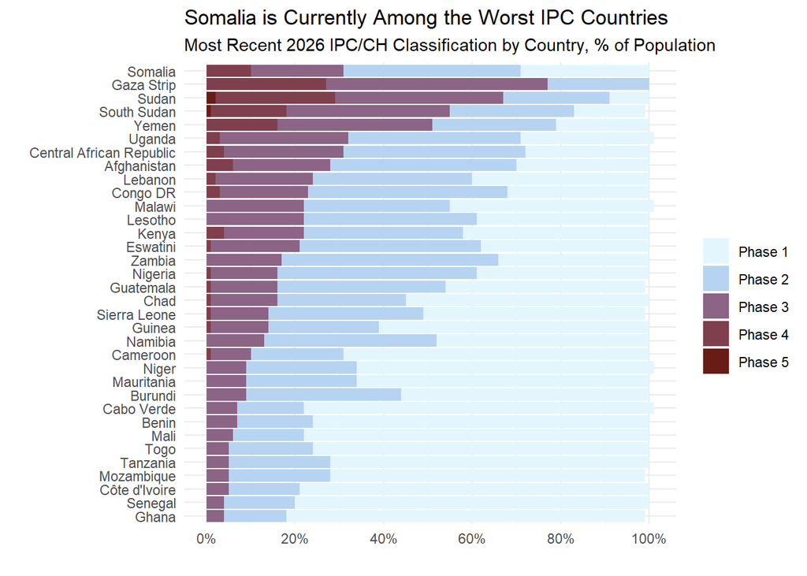

Most recent IPC/CH classification by country, showing the share of population in each phase. Somalia ranks among the most severe globally.

## Stunting

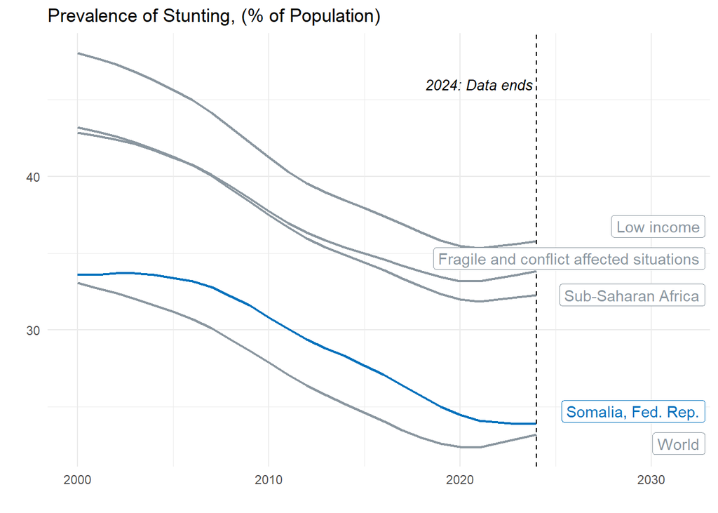

Somalia’s stunting prevalence compared to regional and income-group averages, 2000–2024.

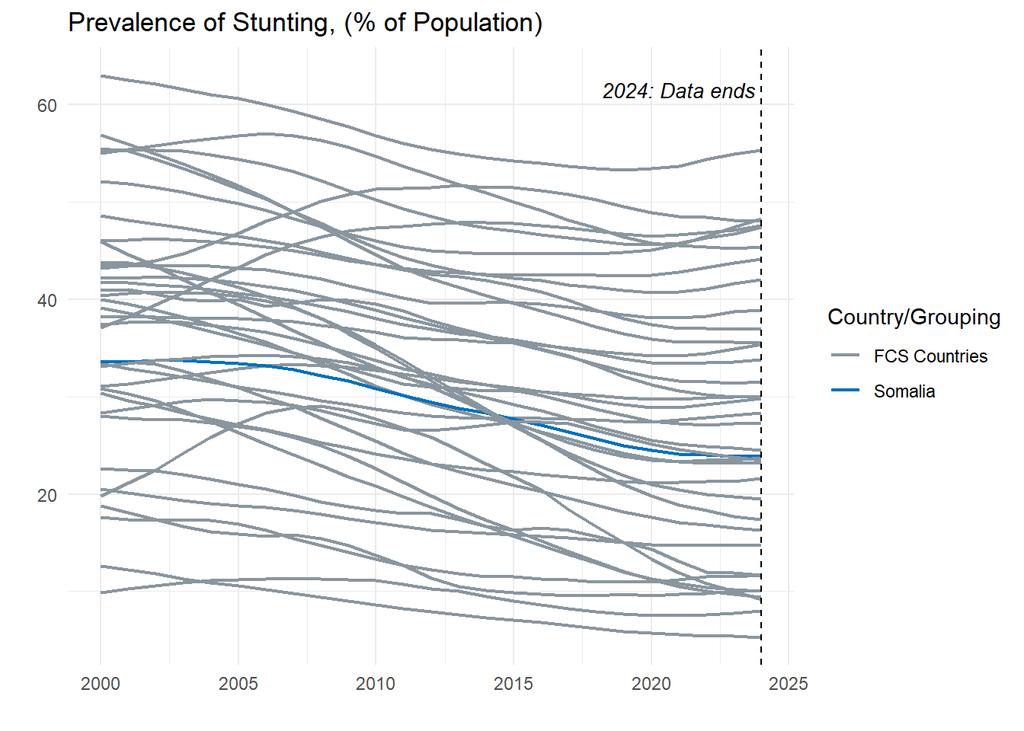

Somalia’s stunting rate against individual FCS country peers, 2000–2024.

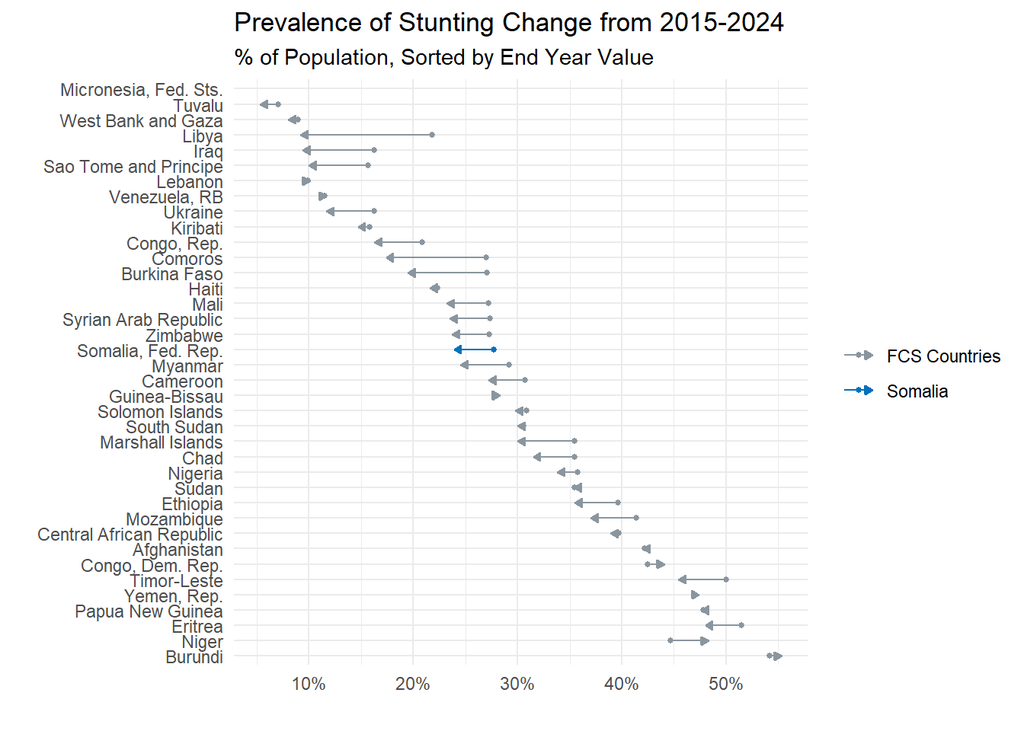

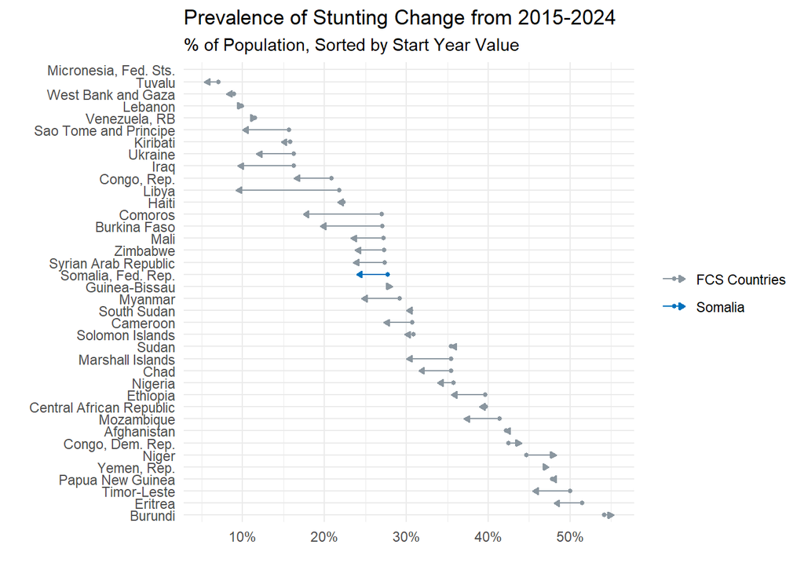

Change in stunting prevalence across FCS countries from 2015 to 2024, ranked by 2024 rate and 2015 rate. Somalia falls in the middle of the group.

## Speed of Progress

### Undernourishment

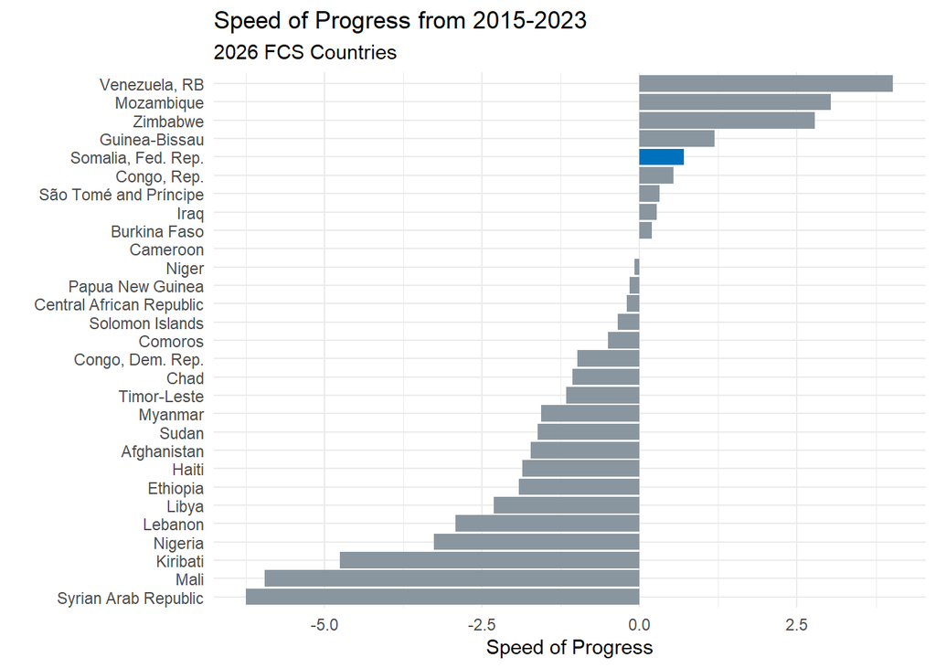

Speed of Progress of undernourishment for Somalia and other FCS Countries, 2015–2023. Speed of progress is calculated by taking historical data, generating a “typical development” path, and comparing the rate of improvement from a given start point. Higher values indicate faster improvement. Despite have a speed score of < 1, it is clear that Somalia is faring better than most FCS Countries.

### Stunting

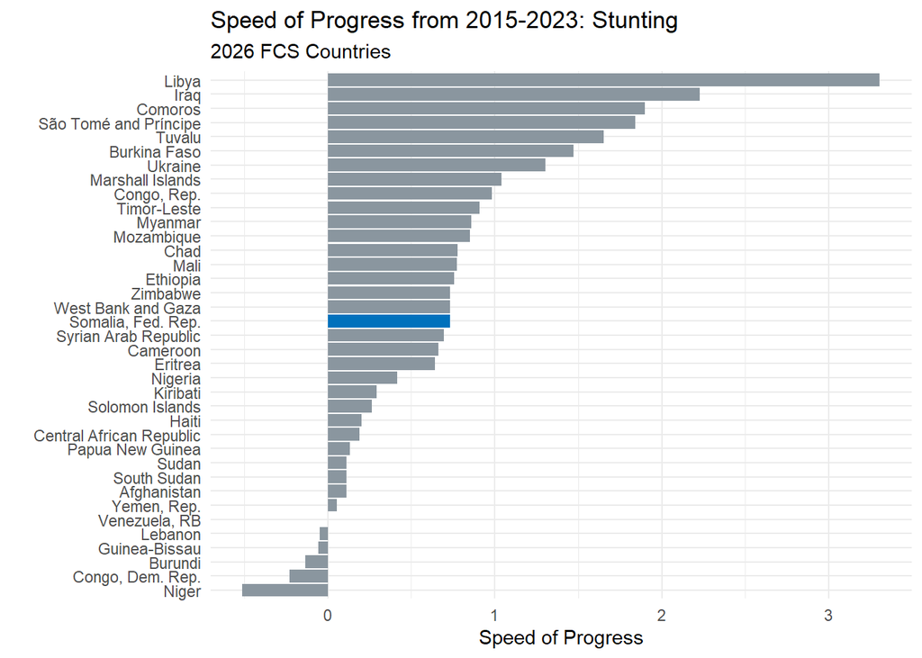

The same graph as above but with stunting.

## Typical Path for Undernourishment and Stunting with Entire World

### Undernourishment

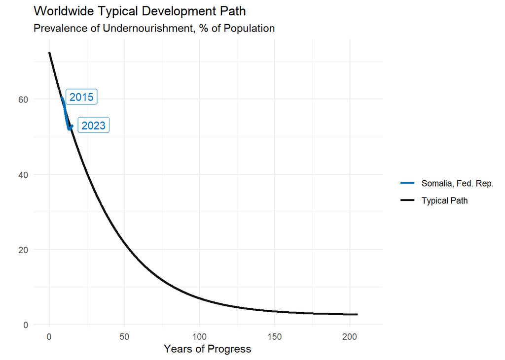

Somalia’s progress from 2015-2023 in undernourishment rates positioned on the typical development path, which maps how countries have historically reduced undernourishment as they develop.

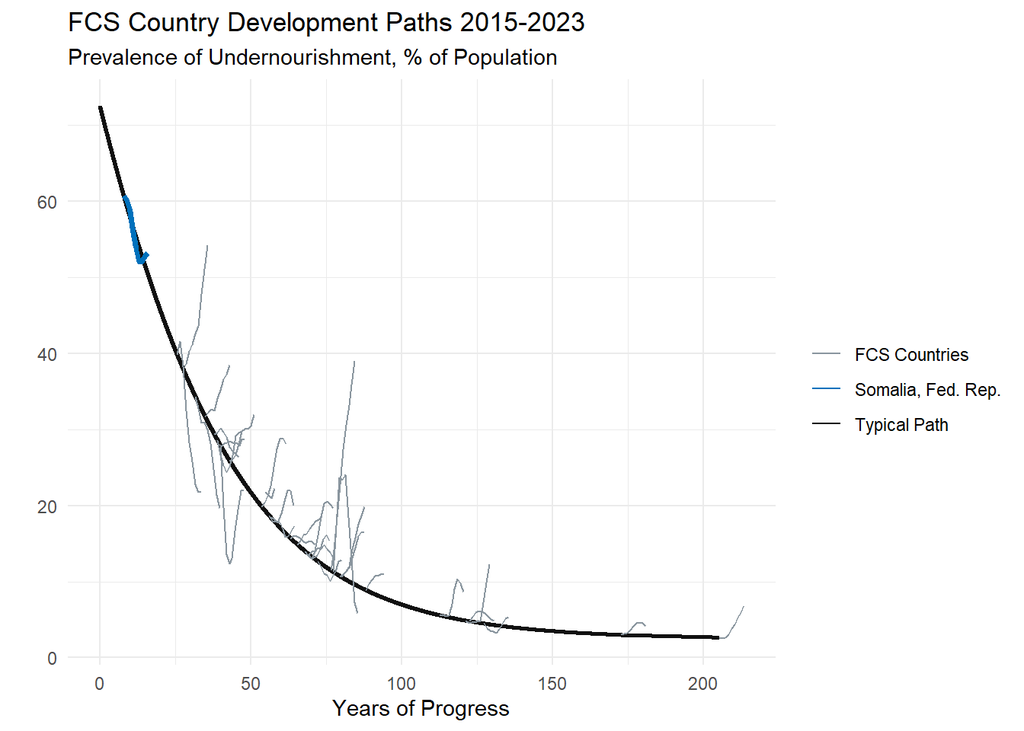

FCS country trajectories overlaid on the typical development path for undernourishment, 2015–2023. Many of the countries trend upward, signalling a regression in this indicator.

### Stunting

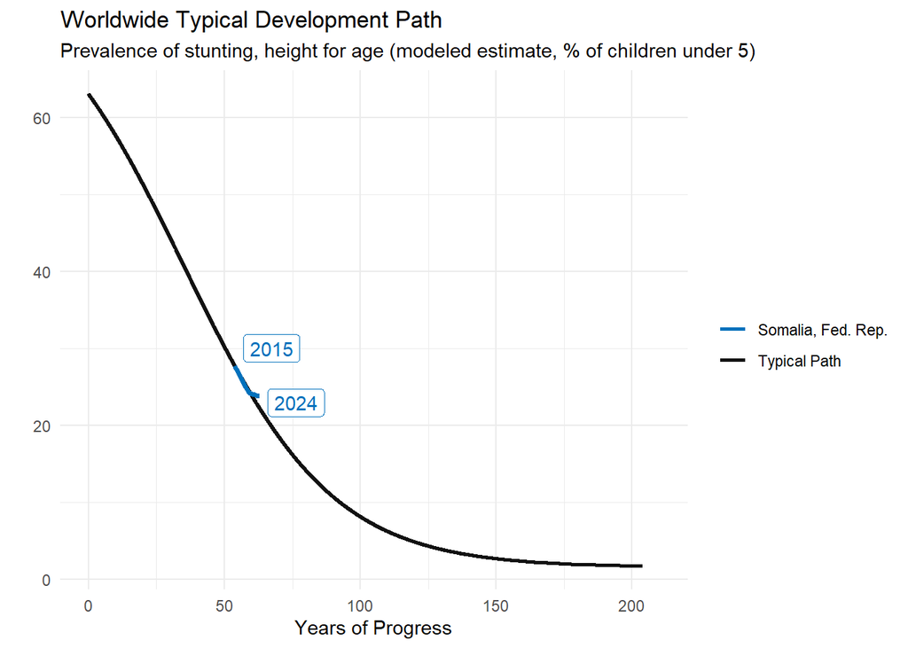

Somalia’s 2015-2024 stunting rate progress on the global typical development path.

[figure not shown]

FCS country trajectories on the typical stunting development path, 2015–2024.